# Assignment #1 ‐ Data set selection and initial Processing

Gen Li

2024-02-15

# Introduction

This notebook records the initial processing of the data GSE199089(Cheng et al. 2022). The data was found in the [GEO](https://www.ncbi.nlm.nih.gov/geo/) database. The codes in the notebook would basically perform the following steps to process the data:

- Automatically download the data
- Compute quality control statistics to assess data quality
- Map the original Gene symbols (Ensembl ID) to HUGO gene symbols and deal with abnormal situations
- Clean the data by removing outliers or data with significant errors
- Apply normalization on the data and generate the data frame as required
- interpret the result and answer questions

Generally, the data comes from a [paper](https://pubmed.ncbi.nlm.nih.gov/35534729/)(Cheng et al. 2022) (please click the link to see the figure), which performs gene expression analysis of lung cancer H1299 cells in response to the presence or absence of glutamine or glucose or NH4+. There are 15 replicates with condition Gln/-, Glu/-, Glu/Gln, Glu/NH4+, control. They perform RNA-sequencing on each sample to obtain the gene expression counts in each replicate.

The Figure.1a in the [paper](https://www.ncbi.nlm.nih.gov/pmc/articles/PMC9177652/figure/F1/)(Cheng et al. 2022) show the result from the paper, and it shows that main idea of the research, which is comparing the differential expression of genes under different treatment of glutamine or glucose or NH4+. It is easy to find that when Gln and Glu appears together, the expression level of Fatty acid and Cholesterol synthesis genes are increased.

The data has genes as its row names, sample IDs/names as its column names, each cell of the matrix contains the expression value of each gene in each sample.

Install all necessary packages(Morgan and Ramos 2023):

```r
# Check if all required packages are installed and install them if not
if (!require("BiocManager", quietly = TRUE))
    install.packages("BiocManager")

if (!require("GEOquery", quietly = TRUE))
    BiocManager::install("GEOquery")

if (!require("knitr", quietly = TRUE))
    install.packages("knitr")

if (!require("edgeR", quietly = TRUE))
    BiocManager::install("edgeR")

if (!require("biomaRt", quietly = TRUE))
    BiocManager::install("biomaRt")

library(GEOquery)
library(knitr)
library(edgeR)
library(biomaRt)
```

# Download Data

I will use the package [GEOquery](https://bioconductor.org/packages/release/bioc/html/GEOquery.html)(Davis and Meltzer 2007) to download the data from GSE199089(Cheng et al. 2022).

```r
# Check if the data has been downloaded to the current wording directory, if yes, the data will not be re-downloaded, if not the data will be downloaded into a newly-created directory
download_dir <- file.path(getwd())
dataset <- "GSE199089"


if (!file.exists(file.path(download_dir,dataset))) {
  print(paste("Downloading Data from GEO to", getwd()))
  getGEOSuppFiles(dataset, makeDirectory = TRUE, baseDir = getwd())
  print("Successfully downloaded!")

} else if (
  file.exists(file.path(download_dir,dataset))
  && file.exists(file.path(download_dir, dataset,
                           paste(dataset, "_raw_counts.txt.gz", sep="")))) {
  print(paste("The data has already been downloaded in", getwd()))
}
```

```
## [1] "Downloading Data from GEO to /home/rstudio/projects"
## [1] "Successfully downloaded!"
```

```r
# Obtain the basic information about the dataset
gse <- getGEO(dataset,GSEMatrix=FALSE)
current_gpl <- names(GPLList(gse))[1]
current_gpl_info <- Meta(getGEO(current_gpl))
```

After downloading the data, we need to got some general information about the data:

- Platform for the data: Illumina NovaSeq 6000 (Homo sapiens)
- Last updated time: Nov 05 2018
- Organism: Homo sapiens

Then I need to load the data into my current R session:

```r
# Load the expression counts in
expression_matrix <- read.table(
  file.path(download_dir, dataset, paste(dataset, "_raw_counts.txt.gz", sep="")),
  header=TRUE, check.names=TRUE)

# Check the dimension and content of the data
print(dim(expression_matrix))
```

```
## [1] 58395    15
```

I also want to check the content of the data:

```r
kable(expression_matrix[1:15,1:15], format = "html", align = 'c')
```

|  | Gln1 | Gln2 | Gln3 | Glu1 | Glu2 | Glu3 | Glu_Gln_1 | Glu_Gln_2 | Glu_Gln_3 | Glu_NH4_1 | Glu_NH4_2 | Glu_NH4_3 | ctrl1 | ctrl2 | ctrl3 |
| --- | --- | --- | --- | --- | --- | --- | --- | --- | --- | --- | --- | --- | --- | --- | --- |
| ENSG00000000003 | 327 | 486 | 362 | 420 | 383 | 364 | 475 | 482 | 547 | 379 | 419 | 382 | 525 | 420 | 477 |
| ENSG00000000005 | 0 | 0 | 1 | 0 | 0 | 0 | 0 | 2 | 1 | 0 | 0 | 0 | 0 | 0 | 0 |
| ENSG00000000419 | 765 | 918 | 740 | 989 | 905 | 919 | 933 | 866 | 974 | 839 | 937 | 832 | 1066 | 827 | 941 |
| ENSG00000000457 | 214 | 264 | 212 | 210 | 234 | 201 | 152 | 160 | 187 | 195 | 228 | 187 | 165 | 110 | 105 |
| ENSG00000000460 | 177 | 231 | 149 | 244 | 232 | 218 | 318 | 359 | 367 | 194 | 224 | 214 | 413 | 330 | 340 |
| ENSG00000000938 | 0 | 0 | 0 | 2 | 0 | 0 | 1 | 0 | 1 | 0 | 0 | 0 | 0 | 1 | 0 |
| ENSG00000000971 | 1 | 3 | 5 | 2 | 2 | 0 | 1 | 5 | 3 | 0 | 3 | 1 | 0 | 2 | 2 |
| ENSG00000001036 | 1770 | 2179 | 1777 | 1879 | 1795 | 1885 | 2073 | 1885 | 2169 | 1926 | 2026 | 1860 | 2714 | 2222 | 2111 |
| ENSG00000001084 | 1002 | 1194 | 979 | 1047 | 965 | 966 | 650 | 587 | 651 | 887 | 954 | 854 | 665 | 556 | 601 |
| ENSG00000001167 | 768 | 960 | 771 | 932 | 916 | 904 | 695 | 639 | 686 | 778 | 871 | 797 | 479 | 369 | 368 |
| ENSG00000001460 | 212 | 246 | 208 | 301 | 329 | 311 | 214 | 247 | 275 | 285 | 275 | 264 | 177 | 115 | 162 |
| ENSG00000001461 | 526 | 592 | 509 | 777 | 739 | 754 | 804 | 723 | 813 | 691 | 746 | 670 | 560 | 544 | 544 |
| ENSG00000001497 | 2057 | 2638 | 2101 | 1892 | 1850 | 1773 | 2568 | 2470 | 2667 | 1735 | 1790 | 1671 | 3567 | 3154 | 3151 |
| ENSG00000001561 | 17 | 25 | 18 | 23 | 16 | 22 | 16 | 27 | 24 | 20 | 31 | 29 | 18 | 19 | 18 |
| ENSG00000001617 | 16 | 33 | 21 | 17 | 19 | 14 | 17 | 24 | 25 | 18 | 24 | 14 | 14 | 9 | 17 |

# Assess and clean and map the data

Check if there are abnormal data, and generate some summary statistics to assess the quality of the data and also filtering the data to exclude low-quality data

```r
# Check if there are negative values in the matrix
if (sum(expression_matrix < 0) != 0) {
  print("There are negative values in the matrix")
} else {
  print("No negative values found")
}
```

```
## [1] "No negative values found"
```

```r
# Check if there are any NA value
if (any(is.na(expression_matrix)) == TRUE) {
  print("There are NA values in the matrix")
} else {
  print("No NA values found")
}
```

```
## [1] "No NA values found"
```

```r
# Check if there are duplications in the Genes
if (length(rownames(expression_matrix)[duplicated(rownames(expression_matrix))]) == 0) {
  print("No Gene duplication")
} else {
  print("Gene Duplications found")
}
```

```
## [1] "No Gene duplication"
```

Calculate the minimum, first quartile, median, third quartile, mean and maximum for each replicate to get the overview of the data(Xie 2023)

```r
kable(t(sapply(expression_matrix[colnames(expression_matrix)], summary)), format = "html", align = 'c')
```

|  | Min. | 1st Qu. | Median | Mean | 3rd Qu. | Max. |
| --- | --- | --- | --- | --- | --- | --- |
| Gln1 | 0 | 0 | 0 | 278.9994 | 15 | 435805 |
| Gln2 | 0 | 0 | 0 | 341.4452 | 19 | 528911 |
| Gln3 | 0 | 0 | 0 | 278.9694 | 16 | 432087 |
| Glu1 | 0 | 0 | 1 | 288.0928 | 19 | 396583 |
| Glu2 | 0 | 0 | 0 | 273.9023 | 17 | 373755 |
| Glu3 | 0 | 0 | 0 | 272.1626 | 16 | 382828 |
| Glu_Gln_1 | 0 | 0 | 0 | 282.9886 | 17 | 331189 |
| Glu_Gln_2 | 0 | 0 | 0 | 267.4155 | 16 | 311570 |
| Glu_Gln_3 | 0 | 0 | 1 | 296.2650 | 19 | 345777 |
| Glu_NH4_1 | 0 | 0 | 0 | 257.4070 | 16 | 370388 |
| Glu_NH4_2 | 0 | 0 | 0 | 275.5197 | 17 | 393989 |
| Glu_NH4_3 | 0 | 0 | 0 | 255.4008 | 16 | 368675 |
| ctrl1 | 0 | 0 | 0 | 322.2226 | 11 | 398866 |
| ctrl2 | 0 | 0 | 0 | 276.0251 | 10 | 341442 |
| ctrl3 | 0 | 0 | 0 | 273.9544 | 9 | 337790 |

No significant abnormality or mistakes could be found, therefore, no need to exclude data at current time. Also, the gene symbol in the expression matrix are Ensembl IDs, which need to be mapped to the HUGO gene symbols, which was maintained by the HUGO Gene Nomenclature Committee ([HGNC](https://www.genenames.org)). To do this, I am going to use the package [biomaRt](https://bioconductor.org/packages/release/bioc/html/biomaRt.html)(Durinck et al. 2005):

```r
# Since gene IDs in the original data are Ensembl IDs, I need to use the "ensembl" mart
ensembl <- useMart("ensembl")

# Obtain all datasets available
datasets <- listDatasets(ensembl)
head(datasets)
```

```
##                        dataset                           description
## 1 abrachyrhynchus_gene_ensembl Pink-footed goose genes (ASM259213v1)
## 2     acalliptera_gene_ensembl      Eastern happy genes (fAstCal1.2)
## 3   acarolinensis_gene_ensembl       Green anole genes (AnoCar2.0v2)
## 4    acchrysaetos_gene_ensembl       Golden eagle genes (bAquChr1.2)
## 5    acitrinellus_gene_ensembl        Midas cichlid genes (Midas_v5)
## 6    amelanoleuca_gene_ensembl       Giant panda genes (ASM200744v2)
##       version
## 1 ASM259213v1
## 2  fAstCal1.2
## 3 AnoCar2.0v2
## 4  bAquChr1.2
## 5    Midas_v5
## 6 ASM200744v2
```

We need to look up the datasets specific for Human, since our data comes from human

```r
# Search for human dataset and choose it
kable(head(datasets[grep(datasets$dataset, pattern = "sapiens"),]), format = "html", align = 'c')
```

|  | dataset | description | version |
| --- | --- | --- | --- |
| 80 | hsapiens_gene_ensembl | Human genes (GRCh38.p14) | GRCh38.p14 |

```r
# Select the dataset for human
ensembl <- useDataset("hsapiens_gene_ensembl", mart=ensembl)
```

Convert the Ensembl ID to HUGO gene symbols

```r
ensg_ids <- rownames(expression_matrix)

#check to see if converted_ids.rds file exists
converted_file <- "converted_ids.rds"
if(file.exists(converted_file)){
  conversion <- readRDS(converted_file)
} else {

  # Convert Ensembl to HUGO
  conversion <- getBM(
    attributes = c("ensembl_gene_id","hgnc_symbol"),
    filters = c("ensembl_gene_id"),
    values = ensg_ids,
    mart = ensembl)

  saveRDS(conversion, converted_file)
}
```

Check the genes that do not have the proper mapping to the HUGO symbol or valid Ensembl ID

```r
# Genes that do not have valid Ensembl IDs in the biomaRt dataset
nrow(expression_matrix) - length(which(rownames(expression_matrix) %in% conversion$ensembl_gene_id))
```

```
## [1] 620
```

```r
# Number of genes that has valid Ensembl ids but no proper mapping to HUGO symbol
sum(conversion$hgnc_symbol == "")
```

```
## [1] 17025
```

```r
removed_blank_hugo <- conversion[!conversion$hgnc_symbol == "",]

# Check if one Ensembl map to multiple HUGO
one2mul <- removed_blank_hugo[duplicated(removed_blank_hugo$ensembl_gene_id),]
one2mul
```

```
##       ensembl_gene_id hgnc_symbol
## 29367 ENSG00000230417   LINC00595
```

I also want to check if one HUGO mapped by multiple Ensembl:

```r
# Check if multiple Ensembl map to one HUGO
mul2one <- removed_blank_hugo[duplicated(removed_blank_hugo$hgnc_symbol),]
mul2one
```

```
##       ensembl_gene_id hgnc_symbol
## 44005 ENSG00000258137   GPR84-AS1
## 44100 ENSG00000258325   ITFG2-AS1
## 44422 ENSG00000258724       PINX1
## 46534 ENSG00000261480     GOLGA8M
## 49675 ENSG00000268500     SIGLEC5
## 51195 ENSG00000271672      DUXAP8
## 51672 ENSG00000272578     GUSBP11
## 56143 ENSG00000280496    SNORA17B
## 56144 ENSG00000280498    SNORA16A
## 56225 ENSG00000281000     SNORD3D
## 56278 ENSG00000281394     SCARNA4
## 56334 ENSG00000281859    SNORD38B
## 56343 ENSG00000281910    SNORA50A
## 56624 ENSG00000283201      ZNF724
## 57625 ENSG00000284988   LINC02203
## 57754 ENSG00000285437     POLR2J3
```

For these genes (both multiple Ensembl map to one HUGO and one Ensembl map to multiple HUGO), since they are in total 17 genes, which is a very small proportion of all genes included, just remove them to simplify the analysis

```r
# remove duplications of symbols in the dataframe
conversion <- conversion[!duplicated(conversion$hgnc_symbol), ]
conversion <- conversion[!duplicated(conversion$ensembl_gene_id), ]

head(conversion)
```

```
##   ensembl_gene_id hgnc_symbol
## 1 ENSG00000000003      TSPAN6
## 2 ENSG00000000005        TNMD
## 3 ENSG00000000419        DPM1
## 4 ENSG00000000457       SCYL3
## 5 ENSG00000000460       FIRRM
## 6 ENSG00000000938         FGR
```

Copy Ensembl IDs to HUGO symbol positions for genes without proper mapping to HUGO symbols and add the mapping information back into the original gene expression data:

```r
# use Ensembl ID for genes that do not have proper HUGO mapping
for (i in 1:length(conversion$hgnc_symbol)) {
  if (conversion[i, 2] == "") {
    conversion[i, 2] <- conversion[i, 1]
  }
}

# add HUGO symbol to the expression matrix
processed_ex_matrix <- cbind(expression_matrix[conversion$ensembl_gene_id,], HUGO = conversion$hgnc_symbol)

# set row names of the expression matrix
row.names(processed_ex_matrix) <- processed_ex_matrix$HUGO

processed_ex_matrix <- processed_ex_matrix[, 1:15]
head(processed_ex_matrix)
```

```
##        Gln1 Gln2 Gln3 Glu1 Glu2 Glu3 Glu_Gln_1 Glu_Gln_2 Glu_Gln_3 Glu_NH4_1
## TSPAN6  327  486  362  420  383  364       475       482       547       379
## TNMD      0    0    1    0    0    0         0         2         1         0
## DPM1    765  918  740  989  905  919       933       866       974       839
## SCYL3   214  264  212  210  234  201       152       160       187       195
## FIRRM   177  231  149  244  232  218       318       359       367       194
## FGR       0    0    0    2    0    0         1         0         1         0
##        Glu_NH4_2 Glu_NH4_3 ctrl1 ctrl2 ctrl3
## TSPAN6       419       382   525   420   477
## TNMD           0         0     0     0     0
## DPM1         937       832  1066   827   941
## SCYL3        228       187   165   110   105
## FIRRM        224       214   413   330   340
## FGR            0         0     0     1     0
```

# Normalization

Since genes with very low counts provide very little evidence for differential expression, we are going to remove genes with low counts, specifically, I am going to filter the genes by counts per million (CPM), because raw counts do not account for library size differences.

```r
# exclude low counts with threshold 6
min_threshold_sample <- 6
data_matrix <- as.matrix(processed_ex_matrix)
genes_remained <- rowSums(cpm(data_matrix) > 1) > min_threshold_sample
filtered_data_matrix <- data_matrix[genes_remained,]
head(filtered_data_matrix)
```

```
##        Gln1 Gln2 Gln3 Glu1 Glu2 Glu3 Glu_Gln_1 Glu_Gln_2 Glu_Gln_3 Glu_NH4_1
## TSPAN6  327  486  362  420  383  364       475       482       547       379
## DPM1    765  918  740  989  905  919       933       866       974       839
## SCYL3   214  264  212  210  234  201       152       160       187       195
## FIRRM   177  231  149  244  232  218       318       359       367       194
## FUCA2  1770 2179 1777 1879 1795 1885      2073      1885      2169      1926
## GCLC   1002 1194  979 1047  965  966       650       587       651       887
##        Glu_NH4_2 Glu_NH4_3 ctrl1 ctrl2 ctrl3
## TSPAN6       419       382   525   420   477
## DPM1         937       832  1066   827   941
## SCYL3        228       187   165   110   105
## FIRRM        224       214   413   330   340
## FUCA2       2026      1860  2714  2222  2111
## GCLC         954       854   665   556   601
```

Here we generate two density plots before and after excluding low count genes for comparison:

```r
# define the function for plotting of density plot
plot_density <- function(input_matrix, title) {
  counts_density <- apply(log2(input_matrix), 2, density)
  #calculate the limits across all the samples
  xlim <- 0
  ylim <- 0

  for (i in 1:length(counts_density)) {
    xlim <- range(c(xlim, counts_density[[i]]$x))
    ylim <- range(c(ylim, counts_density[[i]]$y))
  }
  cols <- rainbow(length(counts_density))
  ltys <- rep(1, length(counts_density))


  # to initialize the plot
  plot(counts_density[[1]], xlim = xlim, ylim = ylim, type="n",
    ylab="Smoothing density of log2-CPM",
    main=title, cex.lab = 0.85)

  #plot each line
  for (i in 1:length(counts_density)) {
    lines(counts_density[[i]], col=cols[i], lty=ltys[i])
  }

  #create legend
  legend("topright", colnames(input_matrix), col=cols, lty=ltys, cex=0.75,
         border ="blue", text.col = "green4",
         merge = TRUE, bg = "gray90")
}
```

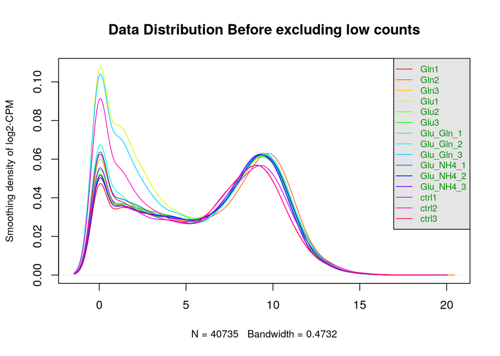

```r
# plot density plot before exclude low
plot_density(data_matrix, "Data Distribution Before excluding low counts")
```

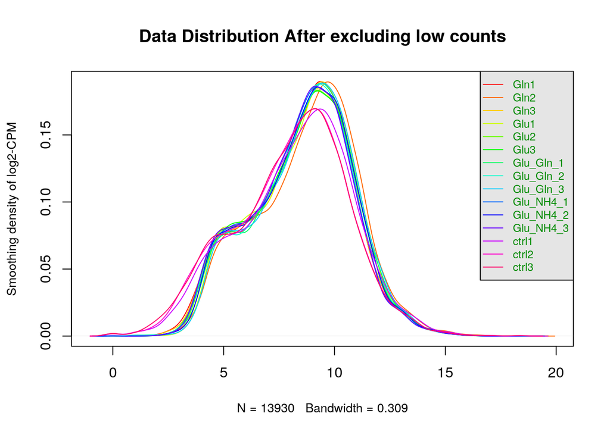

```r
# plot density plot after exclude low
plot_density(filtered_data_matrix, "Data Distribution After excluding low counts")
```

After seeing the difference of the data before and after excluding low counts, I am going to apply the TMM (Trimmed Mean of M-values) normalization technique to my data, since TMM is sample-based, and the data comes from a research that is focusing onn the difference between samples. The normalization uses package edgeR (Robinson, McCarthy, and Smyth 2010)

```r
# Create an edgeR container for RNASeq count data
d <- DGEList(counts = filtered_data_matrix)

# Calculate the normalization factors
d <- calcNormFactors(d)

# obtain the normalized data
normalized_counts <- cpm(d)
```

Here also provide a group of comparison before and after normalization:

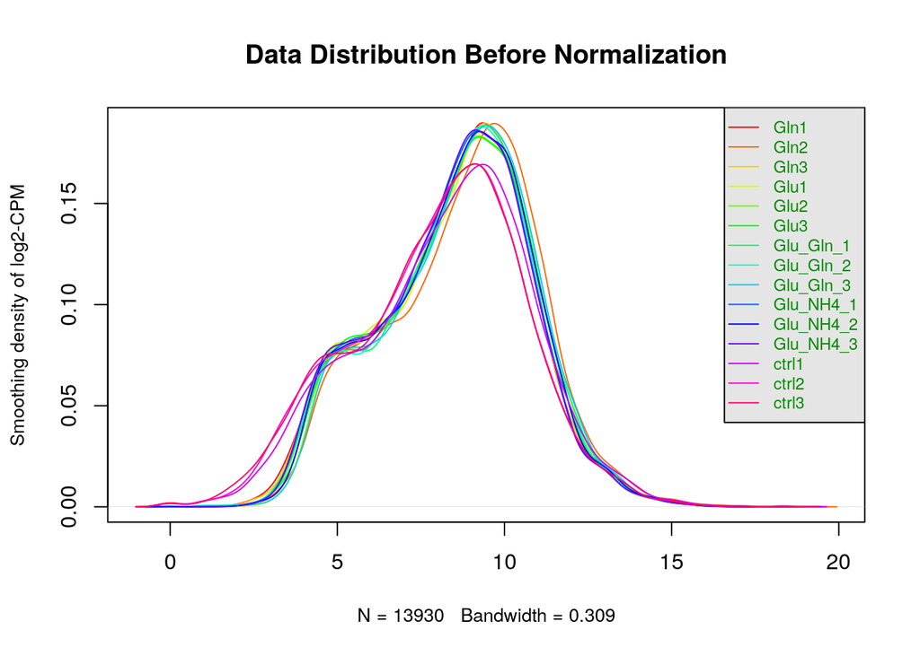

```r
# plot density plot after normalization
plot_density(filtered_data_matrix, "Data Distribution Before Normalization")
```

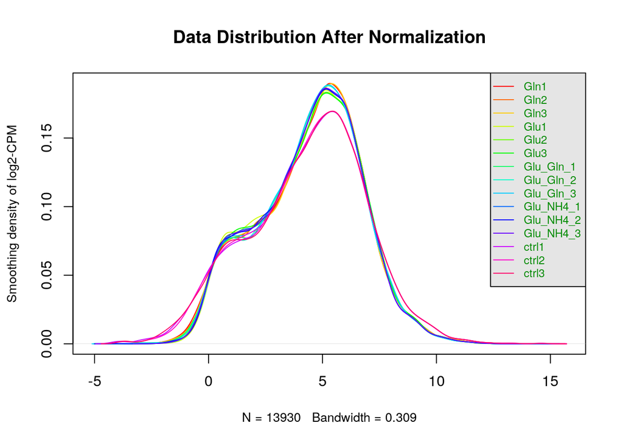

```r
# plot density plot after normalization
plot_density(normalized_counts, "Data Distribution After Normalization")
```

```r
# Check the final processed data
dim(normalized_counts)
```

```
## [1] 13930    15
```

```r
head(as.data.frame(normalized_counts))
```

```
##             Gln1      Gln2       Gln3      Glu1      Glu2      Glu3  Glu_Gln_1
## TSPAN6  20.11897  24.43468  22.224891  23.55118  22.75758  21.80698  26.924333
## DPM1    47.06733  46.15439  45.432098  55.45742  53.77444  55.05664  52.885058
## SCYL3   13.16655  13.27316  13.015682  11.77559  13.90411  12.04177   8.615787
## FIRRM   10.89009  11.61401   9.147814  13.68211  13.78527  13.06023  18.025132
## FUCA2  108.90087 109.55384 109.098429 105.36350 106.65758 112.92901 117.503458
## GCLC    61.64897  60.03088  60.105437  58.70973  57.33959  57.87237  36.843824
##         Glu_Gln_2 Glu_Gln_3 Glu_NH4_1 Glu_NH4_2 Glu_NH4_3     ctrl1      ctrl2
## TSPAN6  28.930316  29.53652  23.64605  24.41495  24.10716  34.59775  32.480146
## DPM1    51.978534  52.59337  52.34574  54.59859  52.50565  70.24990  63.954954
## SCYL3    9.603424  10.09750  12.16617  13.28546  11.80115  10.87358   8.506705
## FIRRM   21.547683  19.81701  12.10378  13.05238  13.50506  27.21690  25.520115
## FUCA2  113.140342 117.12014 120.16435 118.05415 117.38043 178.85388 171.835440
## GCLC    35.232563  35.15224  55.34049  55.58917  53.89402  43.82381  42.997527
##             ctrl3
## TSPAN6  37.207065
## DPM1    73.400101
## SCYL3    8.190234
## FIRRM   26.520759
## FUCA2  164.662713
## GCLC    46.879342
```

```r
saveRDS(as.data.frame(normalized_counts), file.path(getwd(), "normalized_expression_matrix_HUGO.rds"))
```

# Interpret and document

- **Why is the dataset of interest to you?** Since all my undergraduate research projects are about lung cancer and I decided to choose this lung cancer cell-related research dataset. And also, the authors give a relatively clear structure of their data and is easy to manipulate and process. Since I am computational biology track student, and the research itself combines wet experiments with computational technique well, which makes me want to explore. Also, because this is a paper published on Nature Metabolism, which means that it is likely to be an interesting research project.
- **What are the control and test conditions of the dataset?** The control condition is normal lung cancer H1299 cells without adding any of glutamine (Gln) or glucose (Gluc) or NH4+. There are 4 test conditions, which are Gln/- (only glutamine), Glu/- (only glucose), Glu/Gln (both glutamine & glucose), Glu/NH4+ (glucose & NH4+)
- **How many samples in each of the conditions of your dataset?** For each condition mentioned in the last question, 3 samples are included.
- **Were there expression values that were not unique for specific genes? How did you handle these?** In the data I have, I checked that there is no duplicated genes. So I do not need to handle gene duplications. And there are some genes that all have expression values 0 for all samples. In the data processing steps, I did not remove them at first, then when performing the normalization, I set a threshold to remove those low counts in the data. But for other expression values such as some positive numbers that are not filtered by normalization, I did not pay specific attention to them.
- **Were there expression values that could not be mapped to current HUGO symbols?** Yes, there are some genes can not be mapped to HUGO symbols correctly. Some Ensembl IDs can’t be found in the biomaRt dataset (may caused by the retirement of old versions’ Ensembl IDs or biomaRt does not collect all gene Ensembl IDs), and there are some Genes’ Ensembl IDs can be found but no corresponding HUGO symbols to map.
- **Were there any outliers in your dataset? How were they handled in the originating paper? How many outliers were removed?** When I calculate the summary statistics for the data for each sample. I found that samples Gln2 and ctrl1 have relatively high mean value for their gene expression values compared to samples with the same conditions as themselves. But the difference is not significant (not very much high compared to other samples), so I did not remove them. In the paper, the authors did not mentioned how they deal with outliers in detail, they just use a subset of the data to plot.
- **How did you handle replicates?** First, there is no gene duplication in the original data, so I did not do anything. After that, when mapping the Ensembl ID to HUGO symbols, there are some Ensembl IDs mapped to multiple HUGO symbols and also some HUGO symbols mapped by multiple Ensembl IDs, since they are a very tiny proportion of all the data, I removed them to eliminate the potential influence.
- **What is the final coverage of your dataset?** The final coverage of my dataset is 13930 genes in the end, still 15 samples included in the dataset

# References

Cheng, Geng, Li, Zhong, Wang, and Mo Cheng Zhao. 2022. “Ammonia Stimulates SCAP/Insig Dissociation and SREBP-1 Activation to Promote Lipogenesis and Tumor Growth.” *Nature Metabolism* 4: 575--588.

Davis, Sean, and Paul Meltzer. 2007. “GEOquery: A Bridge Between the Gene Expression Omnibus (GEO) and BioConductor.” *Bioinformatics* 14: 1846–47.

Durinck, Steffen, Yves Moreau, Arek Kasprzyk, Sean Davis, Bart De Moor, Alvis Brazma, and Wolfgang Huber. 2005. “BioMart and Bioconductor: A Powerful Link Between Biological Databases and Microarray Data Analysis.” *Bioinformatics* 21: 3439–40.

Morgan, Martin, and Marcel Ramos. 2023. *BiocManager: Access the Bioconductor Project Package Repository*. https://CRAN.R-project.org/package=BiocManager.

Robinson, Mark D, Davis J McCarthy, and Gordon K Smyth. 2010. “edgeR: A Bioconductor Package for Differential Expression Analysis of Digital Gene Expression Data.” *Bioinformatics* 26 (1): 139–40. https://doi.org/10.1093/bioinformatics/btp616.

Xie, Yihui. 2023. *Knitr: A General-Purpose Package for Dynamic Report Generation in r*. https://yihui.org/knitr/.